# A Tutorial of GPCCA Implementation

### 1 Data Preparation

Suppose the R package `GPCCA` is correctly installed. We attach it to the environment.

```r
library(GPCCA)
```

Firstly, we briefly introduce the two example multi-modal datasets provided by the package. They are both synthetic multi-modal datasets with three modalities. There are six groups of samples within each dataset, with ground truth labels given by `example_MultiModalData_labels`. They are similar except for the following difference only:

- `example_MultiModalData_list0`: The dataset is complete with no missing value.
- `example_MultiModalData_list1`: Artificial missing values are introduced, leading to an overall missing rate of 20%.

For simplicity, we assign the ground truth sample labels to `lbls`.

```r
lbls <- example_MultiModalData_labels
```

And we browse the structure of both example datasets (a list that consists of 3 numeric matrices).

```r
str(example_MultiModalData_list0) # complete
```

```
#> List of 3
#>  $ M1: num [1:30, 1:300] 3.09 2.42 -1.81 1.38 2.64 ...
#>  $ M2: num [1:60, 1:300] -3.382 -3.57 0.713 1.278 -0.589 ...
#>  $ M3: num [1:90, 1:300] -1.88 -0.56 -4.85 -3.12 -3.75 ...
```

```r
str(example_MultiModalData_list1) # incomplete
```

```
#> List of 3
#>  $ M1: num [1:30, 1:300] 3.09 2.42 -1.81 1.38 2.64 ...
#>  $ M2: num [1:60, 1:300] -3.382 -3.57 0.713 1.278 -0.589 ...
#>  $ M3: num [1:90, 1:300] NA -0.56 NA -3.12 -3.75 ...
```

### 2 Model Fit

Then, we fit GPCCA model to the incomplete example multi-modal dataset. We specify the size of target dimension to be `d = 4`, i.e. the number of latent factors in low-dimensional subspace. The default value of ridge regularization parameter `lambda = 0.5` is used. Here, we set `verbose = 0` to suppress the printing in every iteration. By default, setting `plot_RMSE = TRUE` generates a plot that helps us monitor the convergence.

```
#> Checking validity of arguments...
#> Checking requirements for the input multi-modal data...
#> Checking consistency between arguments...
#> All checks are passed!
#> Start fitting the GPCCA model...
#> Blockwise inversion of the error covariance matrix is disabled.
```

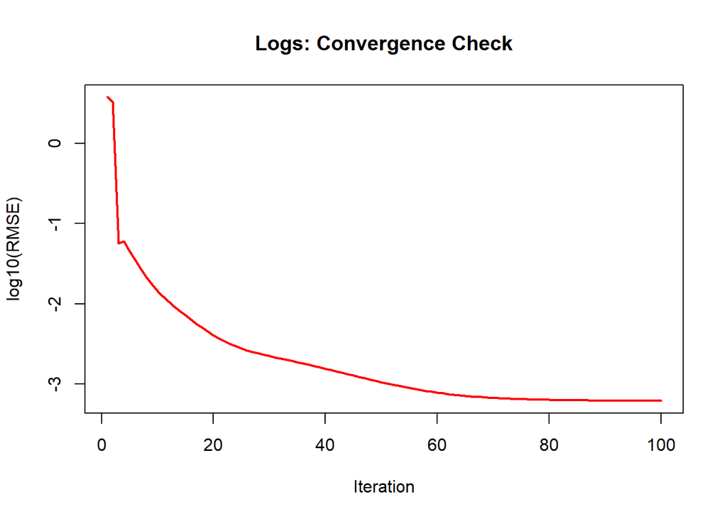

```r
GPCCA.fit <- GPCCAmodel(X.list = example_MultiModalData_list1,
                        d = 4, lambda = 0.5,
                        verbose = 0, plot_RMSE = TRUE)
```

The backend of function `GPCCAmodel` is an EM algorithm. Once the model fitting is completed, we extract the fitted latent factors to `LFs`, i.e. the joint low-dimensional embeddings of the original multi-modal data. The resulting projections extracted can be directly used for any downstream analysis of users’ preference. We will perform an example clustering analysis along with data visualizations a bit later.

```r
LFs <- t(GPCCA.fit$Z)
```

### 3 Downstream Analysis

Next, we attach several more packages for our downstream clustering analysis and visualizations.

```r
library(Seurat)
library(pdfCluster)
library(umap)
library(ggplot2)
```

#### 3.1 Clustering Analysis

To obtain the clustering result, we perform Louvain clustering on the joint low-dimensional embeddings learnt by GPCCA. The labels of identified clusters are stored in a factor object `grps`.

```r
colnames(LFs) <- paste0("LF", 1:ncol(LFs))
rownames(LFs) <- paste0("sample", 1:nrow(LFs))

lc <- FindNeighbors(object = LFs, compute.SNN = TRUE, verbose = FALSE)
lc <- FindClusters(object = lc$snn, verbose = FALSE)

grps <- lc$res.0.8
```

To measure the agreement between the inferred cluster assignment and the true group labels. We compute the Adjusted Rand Index (ARI) and print the confusion matrix.

```r
adj.rand.index(lbls, grps)
```

```
#> [1] 0.8416414
```

```r
table(lbls, grps)
```

```
#>          grps
#> lbls       0  1  2  3  4  5
#>   group 1 48  0  0  0  0  2
#>   group 2  0  8  0  0 42  0
#>   group 3  0 45  0  0  5  0
#>   group 4  7  0  0  0  0 43
#>   group 5  0  0 50  0  0  0
#>   group 6  0  0  0 50  0  0
```

#### 3.2 Visualization

To visualize the fitted latent factors obtained by GPCCA, for example, we create a scatterplot of the first two latent factors.

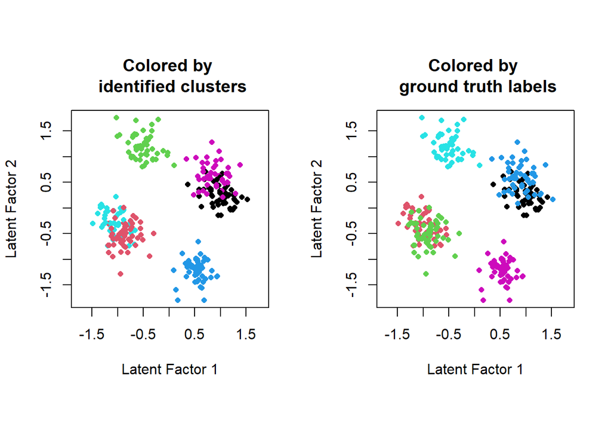

```r
par(pty = "s")
par(mfrow = c(1, 2))
plot(x = LFs[, 1], y = LFs[, 2], col = grps,
     type = "p", pch = 16, cex = 0.8, asp = 1,
     xlab = "Latent Factor 1", ylab = "Latent Factor 2",
     main = "Colored by \n identified clusters")
plot(x = LFs[, 1], y = LFs[, 2], col = factor(lbls),
     type = "p", pch = 16, cex = 0.8, asp = 1,
     xlab = "Latent Factor 1", ylab = "Latent Factor 2",
     main = "Colored by \n ground truth labels")
```

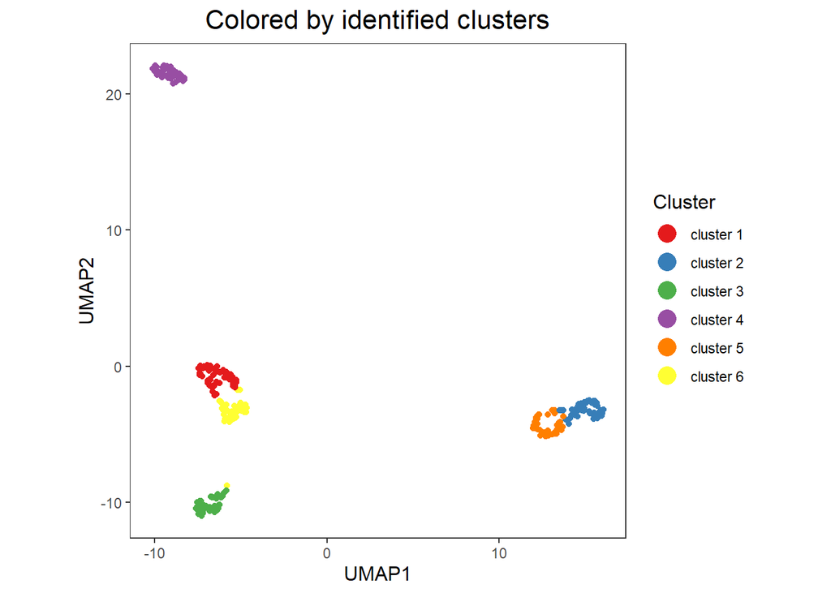

```r
umap_out <- umap(d = LFs)

plotDAT <- data.frame(UMAP1 = umap_out$layout[, 1], UMAP2 = umap_out$layout[, 2],
                      Cluster = as.factor(paste0("cluster ", as.numeric(grps))),
                      Group = as.factor(lbls))

ggplot(plotDAT, aes(x = UMAP1, y = UMAP2, color = Cluster)) + geom_point() + theme_bw() +
  theme(panel.grid.major = element_blank(), panel.grid.minor = element_blank()) +
  scale_color_brewer(palette = "Set1") + theme(aspect.ratio = 1) +
  ggtitle("Colored by identified clusters") +
  theme(plot.title = element_text(hjust = 0.5, size = 16),
        axis.title = element_text(size = 12),
        legend.title = element_text(size = 12)) +
  guides(color = guide_legend(override.aes = list(size = 5)))
```

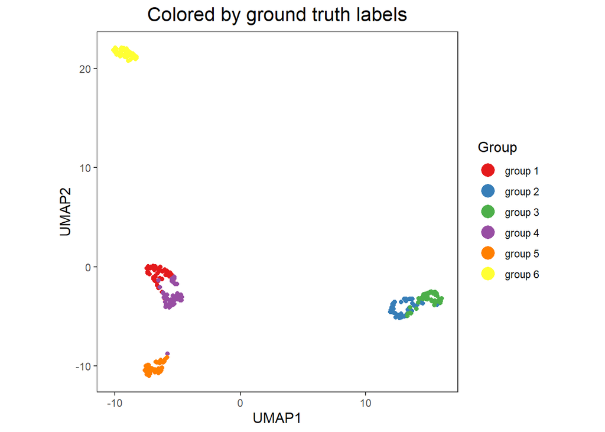

```r
ggplot(plotDAT, aes(x = UMAP1, y = UMAP2, color = Group)) + geom_point() + theme_bw() +
  theme(panel.grid.major = element_blank(), panel.grid.minor = element_blank()) +
  scale_color_brewer(palette = "Set1") + theme(aspect.ratio = 1) +
  ggtitle("Colored by ground truth labels") +
  theme(plot.title = element_text(hjust = 0.5, size = 16),
        axis.title = element_text(size = 12),
        legend.title = element_text(size = 12)) +
  guides(color = guide_legend(override.aes = list(size = 5)))
```

### 4 Model Selection

select the target dimension for GPCCA model on incomplete data…

```r
GPCCA.ds <- GPCCAselect(X.list = example_MultiModalData_list1,
                        d.set = c(2, 4, 6, 8, 10),
                        B = 5, seed = 1234, N.cores = 5)
```

consensus scores of varying target dimensions…

```r
GPCCA.ds$consensus.score
```

[output not shown]

the optimal choice(s) of target dimension…

```r
GPCCA.ds$optim.d
```

[output not shown]